# 财务因子深度分析

陶阿明

2017/06/20

今年以来，市值和反转因子表现不佳，财务因子的关注度得到提升，风水轮流转。每一个因子都有其周期，没有长青的因子，尤其过去几年表现抢眼的因子不可避免的会遇到均值回复宿命。

## 一、因子综述

### (一)因子简介

季度净利润增速的均值除以标准差主要用来衡量净利润增速的稳定性，净利润增速高且增速稳定的公司得分较高。具体的计算为过去三年每个季度净利润同比增速均值除以其标准差，由于要用到过去三年的财务数据，上市不足三年的股票数值为空，用行业中值代替。

### (二)因子效果展示

因子IC序列如下图所示：

```
## [memory data loading]
##   Loading the market trading days: '.tradingdays' ...
##   Loading the SQLite memory database. You can run DBI::dbListTables(.con_memory) to get the loaded table list
```

```
## Function getTSF: getting the factorscore ....
## Tinysoft logined.
```

```
## Function getTSR: getting the periodrtn ....
```

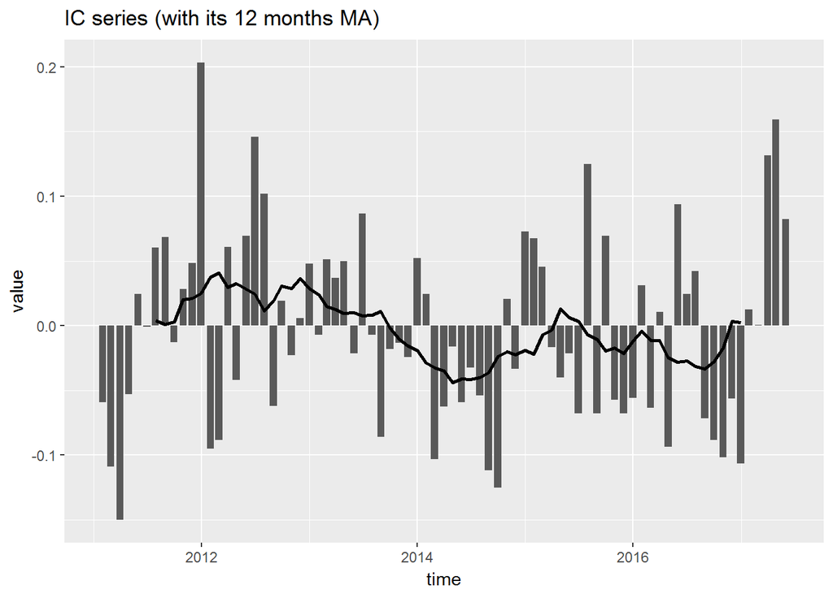

因子分组的年化收益率如下图所示：

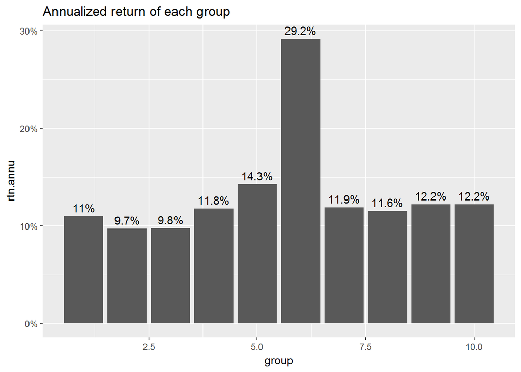

因子多空收益如下图所示：

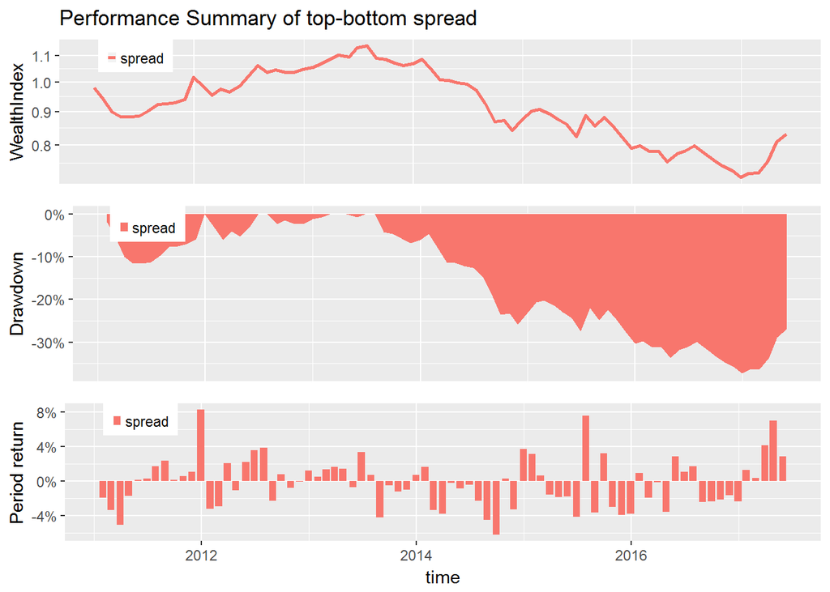

### (三)纯因子组合

上述因子IC、因子分组、因子多空组合不能剥离行业、市值等风格特征。下面构建的纯因子组合是剔除了市值、行业之后的纯因子组合，更能有效的反映因子的alpha性。

纯因子组合收益率如下图所示：

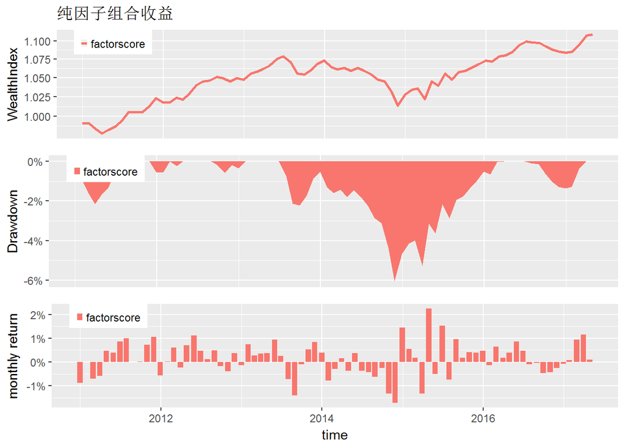

纯因子组合收益率统计如下表：

|  | factorscore |
| --- | --- |
| 2010-12-31 ~ 2010-12-31 | -0.9% |
| 2011-01-31 ~ 2011-12-30 | 2.7% |
| 2012-01-31 ~ 2012-12-31 | 3% |
| 2013-01-31 ~ 2013-12-31 | 2.4% |
| 2014-01-30 ~ 2014-12-31 | -4.2% |
| 2015-01-30 ~ 2015-12-31 | 4.4% |
| 2016-01-29 ~ 2016-12-30 | 1% |
| 2017-01-26 ~ 2017-04-28 | 2.3% |
| Cumulative Return | 10.9% |
| Annualized Return | 1.6% |
| Annualized StdDev | 2.4% |
| Annualized Sharpe(Rf=0%) | 66.8% |
| Worst Drawdown | 6% |

## 二、核心指数回测

上面的测试都是全市场测试，下面将在沪深300和中证500里面分别测试因子的效果。

### (一)沪深300

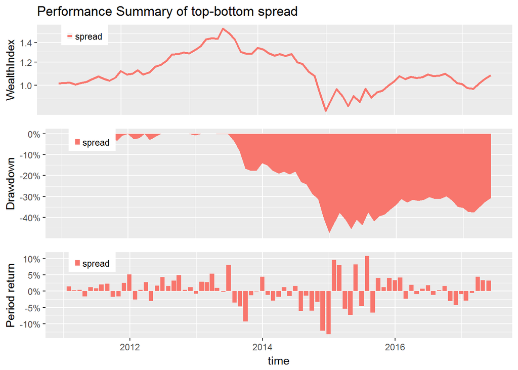

### (二)中证500

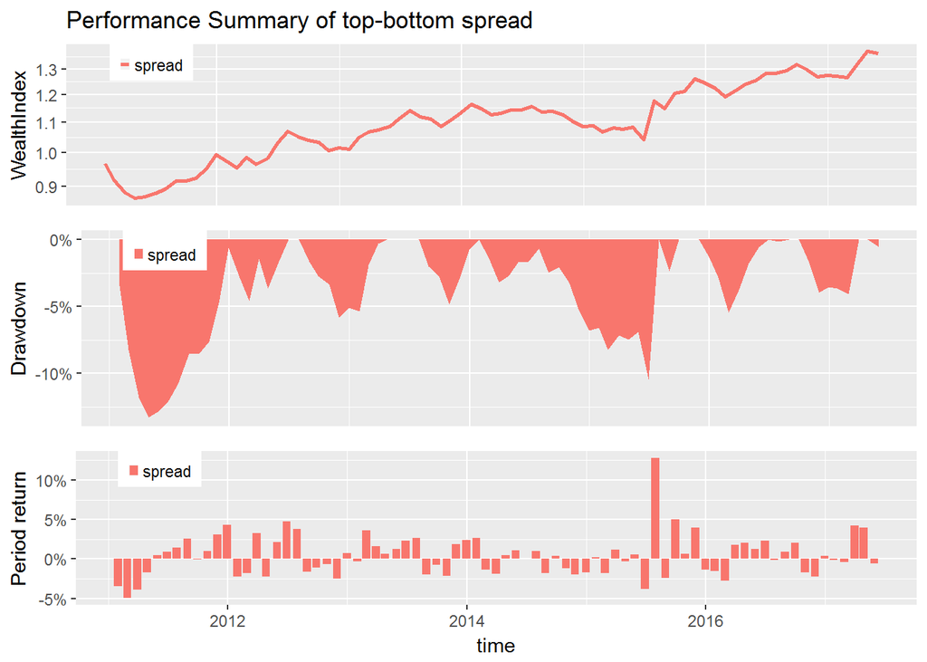

### (三)指数统计

两个指数中因子的IC统计和因子的多空组合收益率如下表所示

|  | EI000300 | EI000905 |
| --- | --- | --- |
| IC均值 | 0.013 | 0.013 |
| IC标准差 | 0.103 | 0.068 |
| ICIR | 0.130 | 0.195 |
| IC胜率 | 0.532 | 0.545 |
| 多空组合年化收益 | 0.012 | 0.050 |
| 多空组合年化波动率 | 0.152 | 0.092 |
| 多空组合年化夏普 | 0.082 | 0.541 |
| 多空组合最大回撤 | 0.475 | 0.133 |

## 三、大类行业回测

### (一)大周期

大周期覆盖农林牧渔、采掘、化工、钢铁、有色金属。

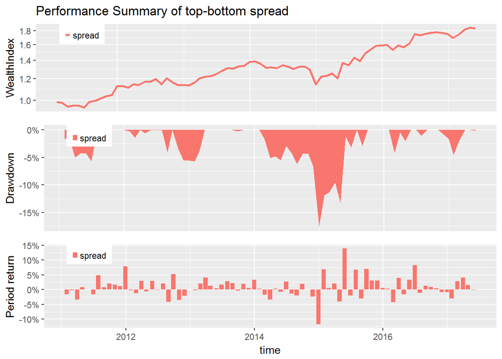

### (二)金融地产

金融地产组覆盖银行、非银、房地产。

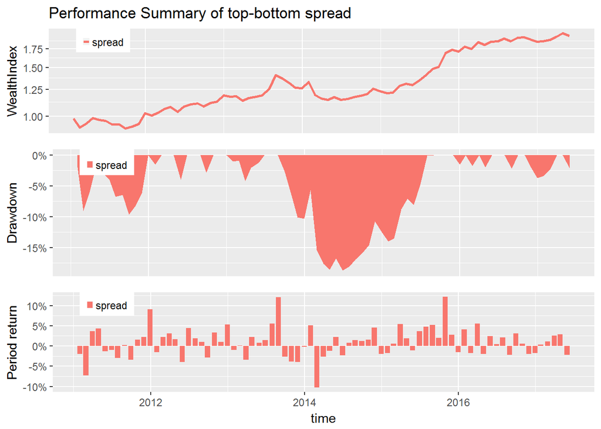

### (三)TMT

TMT覆盖电子、计算机、传媒、通信。

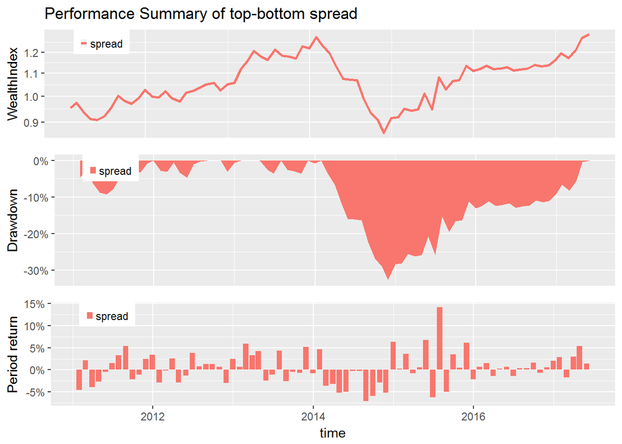

### (四)大消费

大消费覆盖汽车、家用电器、食品饮料、纺织服装、休闲服务、医药生物、商业贸易。

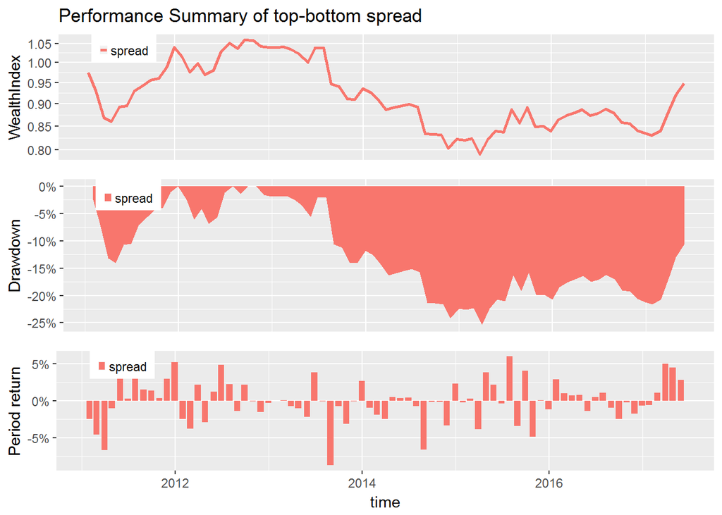

### (五)制造组

制造组覆盖轻工制造、建筑材料、建筑建材、电气设备、机械设备、国防军工。

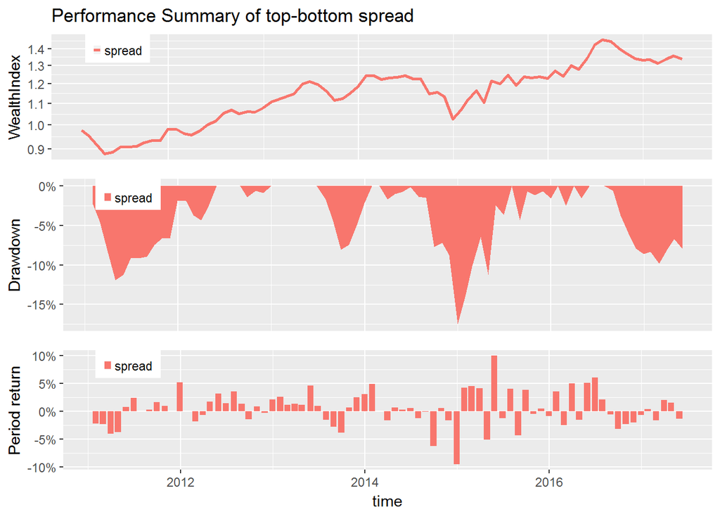

### (六)其他

其他覆盖公共事业、交通运输、综合。

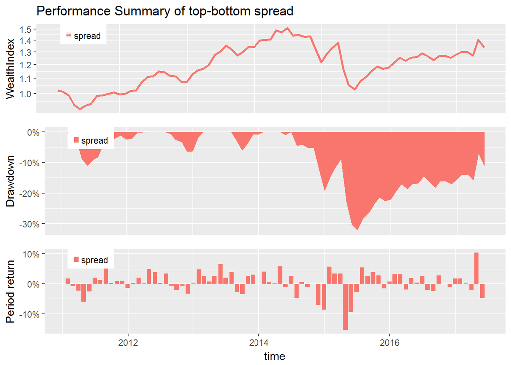

### (七)行业统计

大类行业中因子的IC统计和因子的多空组合收益率如下表所示

|  | 周期 | 金融地产 | TMT | 消费 | 制造 | 其他 |
| --- | --- | --- | --- | --- | --- | --- |
| IC均值 | 0.022 | 0.018 | 0.011 | 0.004 | 0.013 | 0.023 |
| IC标准差 | 0.085 | 0.092 | 0.081 | 0.059 | 0.067 | 0.092 |
| ICIR | 0.253 | 0.200 | 0.141 | 0.071 | 0.200 | 0.249 |
| IC胜率 | 0.558 | 0.597 | 0.519 | 0.506 | 0.558 | 0.649 |
| 多空组合年化收益 | 0.100 | 0.110 | 0.041 | -0.008 | 0.046 | 0.046 |
| 多空组合年化波动率 | 0.120 | 0.127 | 0.125 | 0.098 | 0.106 | 0.134 |
| 多空组合年化夏普 | 0.831 | 0.861 | 0.326 | -0.085 | 0.437 | 0.346 |
| 多空组合最大回撤 | 0.175 | 0.187 | 0.327 | 0.253 | 0.175 | 0.321 |